# v1.0

- General Stats
- FastQC
  - Sequence Quality Histograms
  - Per Sequence Quality Scores
  - Per Base Sequence Content
  - Per Sequence GC Content
  - Per Base N Content
  - Sequence Length Distribution
  - Sequence Duplication Levels
  - Overrepresented sequences
  - Adapter Content

### MultiQC Toolbox

#### Export Plots

**Images**

**Data**

Note that additional data was saved in `multiqc_data` when this report was generated.

##### Choose Plots

If you use plots from MultiQC in a publication or presentation, please cite:

#### About MultiQC

This report was generated using MultiQC, version 1.0

MultiQC is published in Bioinformatics:

A modular tool to aggregate results from bioinformatics analyses across many samples into a single report.

Report generated on 2018-02-03, 14:44 based on data in: `/gpfs/home/b042/greenland_2017/platesA2B2/platesA2B2_combined`

## General Statistics

| Sample Name | % Dups | % GC | Length | % Failed | M Seqs |
| --- | --- | --- | --- | --- | --- |
| Sample_PRO1322_PlateA_A10_R1 | 68.7% | 35% | 126 bp | 25% | 7.7 |
| Sample_PRO1322_PlateA_A10_R2 | 68.8% | 35% | 126 bp | 25% | 7.7 |
| Sample_PRO1322_PlateA_A11_R1 | 77.7% | 34% | 126 bp | 25% | 10.5 |
| Sample_PRO1322_PlateA_A11_R2 | 78.0% | 34% | 126 bp | 25% | 10.5 |
| Sample_PRO1322_PlateA_A12_R1 | 13.7% | 35% | 126 bp | 8% | 0.2 |
| Sample_PRO1322_PlateA_A12_R2 | 13.3% | 35% | 126 bp | 8% | 0.2 |
| Sample_PRO1322_PlateA_A1_R1 | 71.8% | 32% | 126 bp | 25% | 10.2 |
| Sample_PRO1322_PlateA_A1_R2 | 73.0% | 32% | 126 bp | 25% | 10.2 |
| Sample_PRO1322_PlateA_A2_R1 | 68.0% | 35% | 126 bp | 25% | 16.3 |
| Sample_PRO1322_PlateA_A2_R2 | 67.3% | 35% | 126 bp | 25% | 16.3 |
| Sample_PRO1322_PlateA_A3_R1 | 76.0% | 35% | 126 bp | 25% | 12.5 |
| Sample_PRO1322_PlateA_A3_R2 | 75.4% | 35% | 126 bp | 25% | 12.5 |
| Sample_PRO1322_PlateA_A4_R1 | 88.8% | 38% | 126 bp | 42% | 17.0 |
| Sample_PRO1322_PlateA_A4_R2 | 89.4% | 38% | 126 bp | 33% | 17.0 |
| Sample_PRO1322_PlateA_A5_R1 | 67.7% | 32% | 126 bp | 25% | 16.2 |
| Sample_PRO1322_PlateA_A5_R2 | 67.2% | 32% | 126 bp | 25% | 16.2 |
| Sample_PRO1322_PlateA_A6_R1 | 80.5% | 37% | 126 bp | 25% | 16.1 |
| Sample_PRO1322_PlateA_A6_R2 | 80.4% | 37% | 126 bp | 25% | 16.1 |
| Sample_PRO1322_PlateA_A7_R1 | 14.7% | 34% | 126 bp | 17% | 0.1 |
| Sample_PRO1322_PlateA_A7_R2 | 14.7% | 34% | 126 bp | 8% | 0.1 |
| Sample_PRO1322_PlateA_A8_R1 | 74.8% | 36% | 126 bp | 25% | 14.3 |
| Sample_PRO1322_PlateA_A8_R2 | 75.0% | 36% | 126 bp | 25% | 14.3 |
| Sample_PRO1322_PlateA_A9_R1 | 65.7% | 37% | 126 bp | 25% | 22.7 |
| Sample_PRO1322_PlateA_A9_R2 | 64.8% | 37% | 126 bp | 25% | 22.7 |
| Sample_PRO1322_PlateA_B10_R1 | 14.2% | 35% | 126 bp | 17% | 0.5 |
| Sample_PRO1322_PlateA_B10_R2 | 14.2% | 35% | 126 bp | 8% | 0.5 |
| Sample_PRO1322_PlateA_B11_R1 | 73.6% | 33% | 126 bp | 25% | 16.0 |
| Sample_PRO1322_PlateA_B11_R2 | 73.4% | 33% | 126 bp | 25% | 16.0 |
| Sample_PRO1322_PlateA_B12_R1 | 57.7% | 33% | 126 bp | 25% | 17.4 |
| Sample_PRO1322_PlateA_B12_R2 | 57.1% | 33% | 126 bp | 25% | 17.4 |

[output cut: 80 more lines]

## FastQC

[FastQC](http://www.bioinformatics.babraham.ac.uk/projects/fastqc/) is a quality control tool for high throughput sequence data, written by Simon Andrews at the Babraham Institute in Cambridge.

### Sequence Quality Histograms

The mean quality value across each base position in the read. See the [FastQC help](http://www.bioinformatics.babraham.ac.uk/projects/fastqc/Help/3%20Analysis%20Modules/2%20Per%20Base%20Sequence%20Quality.html).

Flat image plot. Toolbox functions such as highlighting / hiding samples will not work (see the [docs](http://multiqc.info/docs/#flat--interactive-plots)).

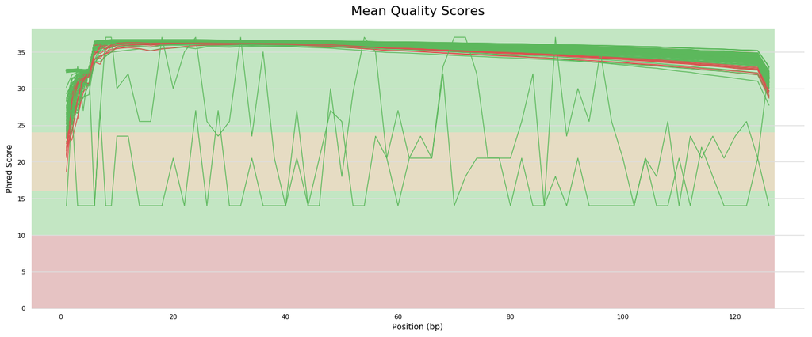

### Per Sequence Quality Scores

The number of reads with average quality scores. Shows if a subset of reads has poor quality. See the [FastQC help](http://www.bioinformatics.babraham.ac.uk/projects/fastqc/Help/3%20Analysis%20Modules/3%20Per%20Sequence%20Quality%20Scores.html).

Flat image plot. Toolbox functions such as highlighting / hiding samples will not work (see the [docs](http://multiqc.info/docs/#flat--interactive-plots)).

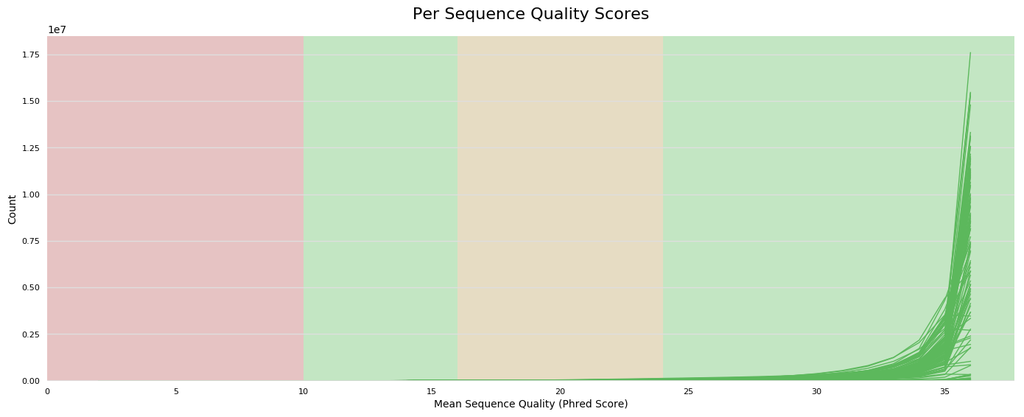

### Per Base Sequence Content

The proportion of each base position for which each of the four normal DNA bases has been called. See the [FastQC help](http://www.bioinformatics.babraham.ac.uk/projects/fastqc/Help/3%20Analysis%20Modules/4%20Per%20Base%20Sequence%20Content.html).

Click a sample row to see a line plot for that dataset.

[interactive chart not shown]

### Per Sequence GC Content

The average GC content of reads. Normal random library typically have a roughly normal distribution of GC content. See the [FastQC help](http://www.bioinformatics.babraham.ac.uk/projects/fastqc/Help/3%20Analysis%20Modules/5%20Per%20Sequence%20GC%20Content.html).

Flat image plot. Toolbox functions such as highlighting / hiding samples will not work (see the [docs](http://multiqc.info/docs/#flat--interactive-plots)).

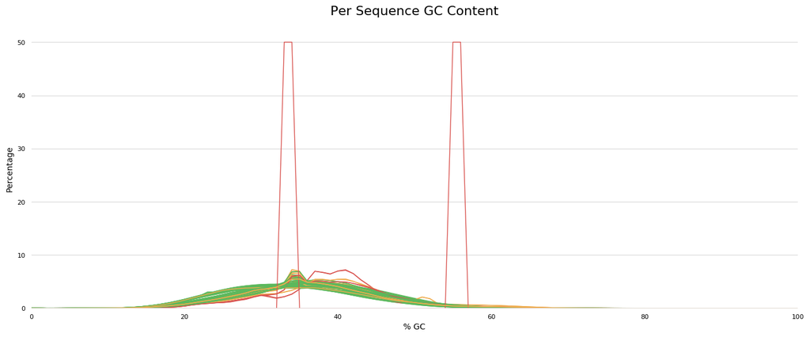

### Per Base N Content

The percentage of base calls at each position for which an N was called. See the [FastQC help](http://www.bioinformatics.babraham.ac.uk/projects/fastqc/Help/3%20Analysis%20Modules/6%20Per%20Base%20N%20Content.html).

Flat image plot. Toolbox functions such as highlighting / hiding samples will not work (see the [docs](http://multiqc.info/docs/#flat--interactive-plots)).

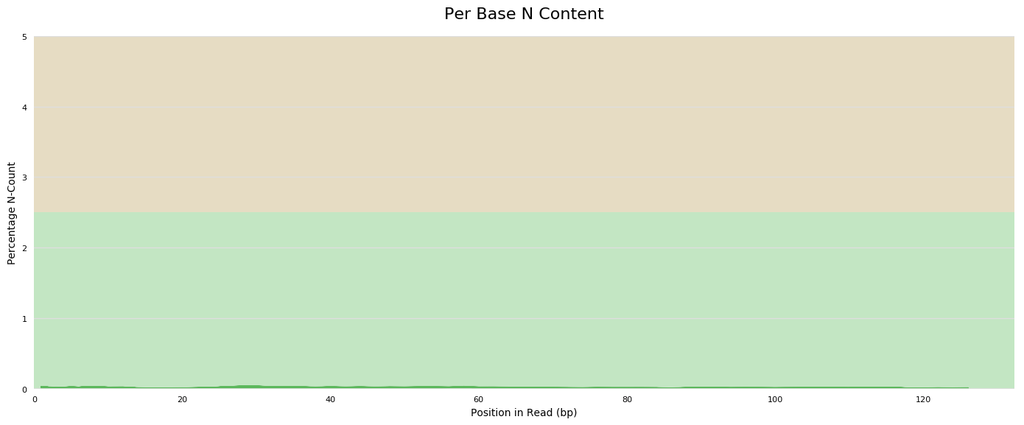

### Sequence Length Distribution

All samples have sequences of a single length (126bp).

### Sequence Duplication Levels

The relative level of duplication found for every sequence. See the [FastQC help](http://www.bioinformatics.babraham.ac.uk/projects/fastqc/Help/3%20Analysis%20Modules/8%20Duplicate%20Sequences.html).

Flat image plot. Toolbox functions such as highlighting / hiding samples will not work (see the [docs](http://multiqc.info/docs/#flat--interactive-plots)).

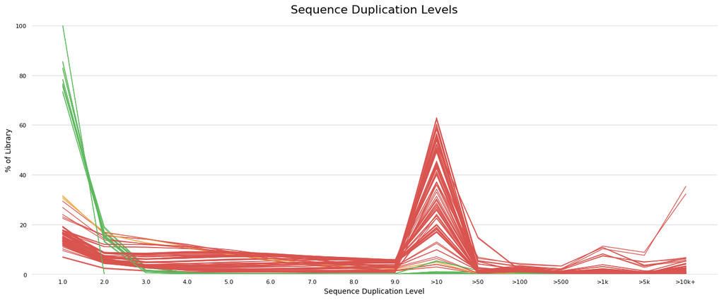

### Overrepresented sequences

The total amount of overrepresented sequences found in each library. See the [FastQC help for further information](http://www.bioinformatics.babraham.ac.uk/projects/fastqc/Help/3%20Analysis%20Modules/9%20Overrepresented%20Sequences.html).

Flat image plot. Toolbox functions such as highlighting / hiding samples will not work (see the [docs](http://multiqc.info/docs/#flat--interactive-plots)).

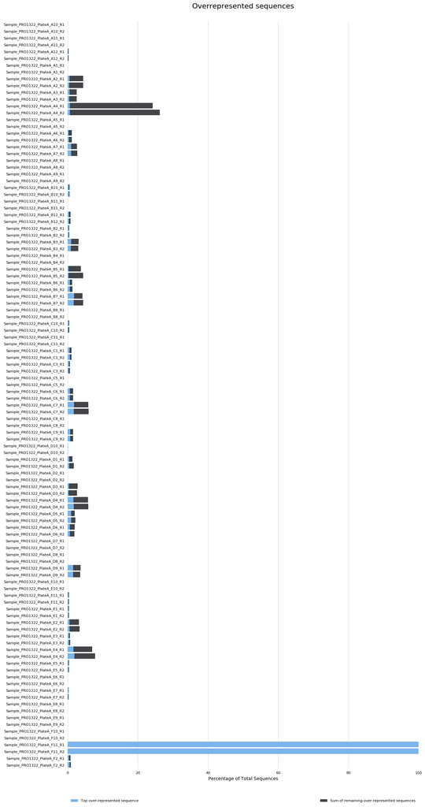

### Adapter Content

The cumulative percentage count of the proportion of your library which has seen each of the adapter sequences at each position. See the [FastQC help](http://www.bioinformatics.babraham.ac.uk/projects/fastqc/Help/3%20Analysis%20Modules/10%20Adapter%20Content.html). Only samples with ≥ 0.1% adapter contamination are shown.

Flat image plot. Toolbox functions such as highlighting / hiding samples will not work (see the [docs](http://multiqc.info/docs/#flat--interactive-plots)).

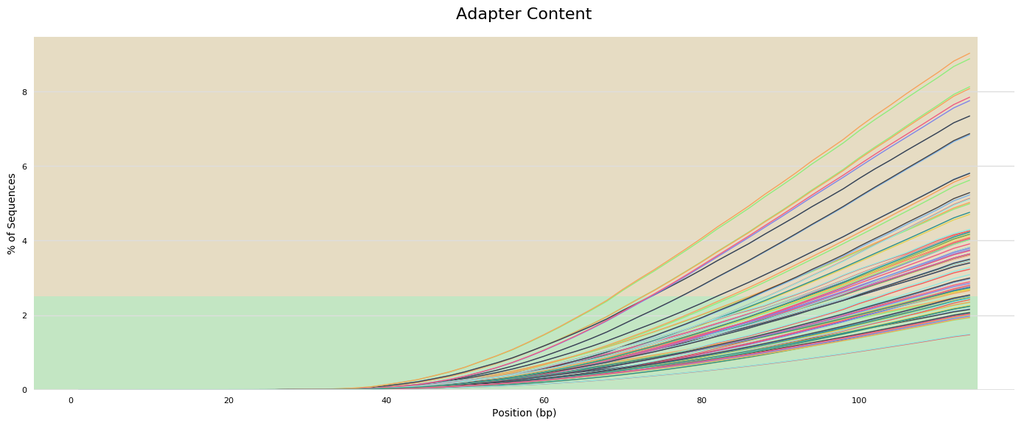

**[MultiQC v1.0](http://multiqc.info)** - Written by [Phil Ewels](http://phil.ewels.co.uk), available on [GitHub](https://github.com/ewels/MultiQC).